# Analysis of FitBit Fitness Tracker Data for Bellabeat

Wadi Wahyudin

2024-06-20

This is a dataset about [FitBit Fitness Tracker Data for Bellabeat](https://www.kaggle.com/datasets/arashnic/fitbit), if you want to know me you can click this link > [Personal Site](https://reaperizy.github.io/personal-site/index.html) I have experience in:

- Data Analyst
- Mobile Developer
- Game Developer
- Web Developer

Okay, to the next step!!!

#### Installing and loading common packages and libraries

```r
library(tidyverse)
library(data.table)
```

## Load CSV files

Here we’ll create a dataframe named ‘daily_activity’ and read in one of the CSV files from the dataset.

```r
daily_activity <- read.csv("dailyActivity_merged.csv")
```

Create another dataframe for the sleep data.

```r
sleep_day <- read.csv("sleepDay_merged.csv")
```

Create another dataframe for weight_log.

```r
 weight_log <- read.csv("weightLogInfo_merged.csv")
```

Create another dataframe for hourly_intensities.

```r
 hourly_intensities <- read.csv("hourlyIntensities_merged.csv")
```

Create another dataframe for hourly_calories.

```r
 hourly_calories <- read.csv("hourlyCalories_merged.csv")
```

Create another dataframe for hourly_steps.

```r
 hourly_steps <- read.csv("hourlySteps_merged.csv")
```

## Exploring a few key tables

Take a look at the daily_activity data.

```r
as_tibble(daily_activity)
```

```
## # A tibble: 940 × 15
##            Id ActivityDate TotalSteps TotalDistance TrackerDistance
##         <dbl> <chr>             <int>         <dbl>           <dbl>
##  1 1503960366 4/12/2016         13162          8.5             8.5
##  2 1503960366 4/13/2016         10735          6.97            6.97
##  3 1503960366 4/14/2016         10460          6.74            6.74
##  4 1503960366 4/15/2016          9762          6.28            6.28
##  5 1503960366 4/16/2016         12669          8.16            8.16
##  6 1503960366 4/17/2016          9705          6.48            6.48
##  7 1503960366 4/18/2016         13019          8.59            8.59
##  8 1503960366 4/19/2016         15506          9.88            9.88
##  9 1503960366 4/20/2016         10544          6.68            6.68
## 10 1503960366 4/21/2016          9819          6.34            6.34
## # ℹ 930 more rows
## # ℹ 10 more variables: LoggedActivitiesDistance <dbl>,
## #   VeryActiveDistance <dbl>, ModeratelyActiveDistance <dbl>,
## #   LightActiveDistance <dbl>, SedentaryActiveDistance <dbl>,
## #   VeryActiveMinutes <int>, FairlyActiveMinutes <int>,
## #   LightlyActiveMinutes <int>, SedentaryMinutes <int>, Calories <int>
```

Take a look at the weight_log data.

```r
as_tibble(weight_log)
```

```
## # A tibble: 67 × 7
##            Id Date             WeightKg WeightPounds   BMI IsManualReport LogId
##         <dbl> <chr>               <dbl>        <dbl> <dbl> <lgl>          <chr>
##  1 1503960366 05/02/2016 23:59     52.6         116.  22.6 TRUE           1,46E…
##  2 1503960366 05/03/2016 23:59     52.6         116.  22.6 TRUE           1,46E…
##  3 1927972279 04/13/2016 1:08     134.          294.  47.5 FALSE          1,46E…
##  4 2873212765 04/21/2016 23:59     56.7         125   21.4 TRUE           1,46E…
##  5 2873212765 05/12/2016 23:59     57.3         126.  21.7 TRUE           1,46E…
##  6 4319703577 04/17/2016 23:59     72.4         160.  27.4 TRUE           1,46E…
##  7 4319703577 05/04/2016 23:59     72.3         159.  27.4 TRUE           1,46E…
##  8 4558609924 04/18/2016 23:59     69.7         154.  27.2 TRUE           1,46E…
##  9 4558609924 04/25/2016 23:59     70.3         155.  27.5 TRUE           1,46E…
## 10 4558609924 05/01/2016 23:59     69.9         154.  27.3 TRUE           1,46E…
## # ℹ 57 more rows
```

Take a look at the sleep_day data.

```r
as_tibble(sleep_day)
```

```
## # A tibble: 413 × 5
##            Id SleepDay       TotalSleepRecords TotalMinutesAsleep TotalTimeInBed
##         <dbl> <chr>                      <int>              <int>          <int>
##  1 1503960366 4/12/2016 12:…                 1                327            346
##  2 1503960366 4/13/2016 12:…                 2                384            407
##  3 1503960366 4/15/2016 12:…                 1                412            442
##  4 1503960366 4/16/2016 12:…                 2                340            367
##  5 1503960366 4/17/2016 12:…                 1                700            712
##  6 1503960366 4/19/2016 12:…                 1                304            320
##  7 1503960366 4/20/2016 12:…                 1                360            377
##  8 1503960366 4/21/2016 12:…                 1                325            364
##  9 1503960366 4/23/2016 12:…                 1                361            384
## 10 1503960366 4/24/2016 12:…                 1                430            449
## # ℹ 403 more rows
```

Take a look at the daily_intensities data.

```r
as_tibble(hourly_intensities)
```

```
## # A tibble: 12,455 × 4
##            Id ActivityHour       TotalIntensity AverageIntensity
##         <dbl> <chr>                       <int>            <dbl>
##  1 1503960366 05/01/2016 0:00:00              9             0.15
##  2 1624580081 05/01/2016 0:00:00              1            16.7
##  3 1844505072 05/01/2016 0:00:00             39             0.65
##  4 2320127002 05/01/2016 0:00:00             15             0.25
##  5 3372868164 05/01/2016 0:00:00              2            33.3
##  6 4388161847 05/01/2016 0:00:00              1            16.7
##  7 4445114986 05/01/2016 0:00:00              8           133.
##  8 6775888955 05/01/2016 0:00:00             29           483.
##  9 6962181067 05/01/2016 0:00:00              1            16.7
## 10 7086361926 05/01/2016 0:00:00              5            83.3
## # ℹ 12,445 more rows
```

Take a look at the daily_calories data.

```r
as_tibble(hourly_calories)
```

```
## # A tibble: 22,099 × 3
##            Id ActivityHour          Calories
##         <dbl> <chr>                    <int>
##  1 1503960366 4/12/2016 12:00:00 AM       81
##  2 1503960366 4/12/2016 1:00:00 AM        61
##  3 1503960366 4/12/2016 2:00:00 AM        59
##  4 1503960366 4/12/2016 3:00:00 AM        47
##  5 1503960366 4/12/2016 4:00:00 AM        48
##  6 1503960366 4/12/2016 5:00:00 AM        48
##  7 1503960366 4/12/2016 6:00:00 AM        48
##  8 1503960366 4/12/2016 7:00:00 AM        47
##  9 1503960366 4/12/2016 8:00:00 AM        68
## 10 1503960366 4/12/2016 9:00:00 AM       141
## # ℹ 22,089 more rows
```

Take a look at the daily_steps data.

```r
as_tibble(hourly_steps)
```

```
## # A tibble: 12,802 × 3
##            Id ActivityHour       StepTotal
##         <dbl> <chr>                  <int>
##  1 1503960366 4/12/2016 0:00:00        373
##  2 1503960366 4/12/2016 1:00:00        160
##  3 1503960366 4/12/2016 2:00:00        151
##  4 1503960366 4/12/2016 8:00:00        250
##  5 1503960366 4/12/2016 9:00:00       1864
##  6 1503960366 4/12/2016 10:00:00       676
##  7 1503960366 4/12/2016 11:00:00       360
##  8 1503960366 4/12/2016 12:00:00       253
##  9 1503960366 4/12/2016 13:00:00       221
## 10 1503960366 4/12/2016 14:00:00      1166
## # ℹ 12,792 more rows
```

Identify all the columsn in the daily_activity data.

```r
colnames(daily_activity)
```

```
##  [1] "Id"                       "ActivityDate"
##  [3] "TotalSteps"               "TotalDistance"
##  [5] "TrackerDistance"          "LoggedActivitiesDistance"
##  [7] "VeryActiveDistance"       "ModeratelyActiveDistance"
##  [9] "LightActiveDistance"      "SedentaryActiveDistance"
## [11] "VeryActiveMinutes"        "FairlyActiveMinutes"
## [13] "LightlyActiveMinutes"     "SedentaryMinutes"
## [15] "Calories"
```

Take a look at the sleep_day data.

```r
head(sleep_day)
```

```
##           Id              SleepDay TotalSleepRecords TotalMinutesAsleep
## 1 1503960366 4/12/2016 12:00:00 AM                 1                327
## 2 1503960366 4/13/2016 12:00:00 AM                 2                384
## 3 1503960366 4/15/2016 12:00:00 AM                 1                412
## 4 1503960366 4/16/2016 12:00:00 AM                 2                340
## 5 1503960366 4/17/2016 12:00:00 AM                 1                700
## 6 1503960366 4/19/2016 12:00:00 AM                 1                304
##   TotalTimeInBed
## 1            346
## 2            407
## 3            442
## 4            367
## 5            712
## 6            320
```

Identify all the columsn in the daily_activity data.

```r
colnames(daily_activity)
```

```
##  [1] "Id"                       "ActivityDate"
##  [3] "TotalSteps"               "TotalDistance"
##  [5] "TrackerDistance"          "LoggedActivitiesDistance"
##  [7] "VeryActiveDistance"       "ModeratelyActiveDistance"
##  [9] "LightActiveDistance"      "SedentaryActiveDistance"
## [11] "VeryActiveMinutes"        "FairlyActiveMinutes"
## [13] "LightlyActiveMinutes"     "SedentaryMinutes"
## [15] "Calories"
```

Identify all the columsn in the sleep_day data.

```r
colnames(sleep_day)
```

```
## [1] "Id"                 "SleepDay"           "TotalSleepRecords"
## [4] "TotalMinutesAsleep" "TotalTimeInBed"
```

Identify all the columsn in the weight_log data.

```r
colnames(weight_log)
```

```
## [1] "Id"             "Date"           "WeightKg"       "WeightPounds"
## [5] "BMI"            "IsManualReport" "LogId"
```

Identify all the columsn in the daily_intensities data.

```r
colnames(hourly_intensities)
```

```
## [1] "Id"               "ActivityHour"     "TotalIntensity"   "AverageIntensity"
```

Identify all the columsn in the daily_calories data.

```r
colnames(hourly_calories)
```

```
## [1] "Id"           "ActivityHour" "Calories"
```

Identify all the columsn in the daily_steps data.

```r
colnames(hourly_steps)
```

```
## [1] "Id"           "ActivityHour" "StepTotal"
```

## Understanding some summary statistics

See how many unique participants are there in each dataframe

```r
n_distinct(daily_activity$Id)
```

```
## [1] 33
```

```r
n_distinct(sleep_day$Id)
```

```
## [1] 24
```

```r
n_distinct(weight_log$Id)
```

```
## [1] 8
```

```r
n_distinct(hourly_intensities$Id)
```

```
## [1] 33
```

```r
n_distinct(hourly_calories$Id)
```

```
## [1] 33
```

```r
n_distinct(hourly_steps$Id)
```

```
## [1] 33
```

See how many observations are there in each dataframe

```r
nrow(daily_activity)
```

```
## [1] 940
```

```r
nrow(sleep_day)
```

```
## [1] 413
```

```r
nrow(weight_log)
```

```
## [1] 67
```

```r
nrow(hourly_intensities)
```

```
## [1] 12455
```

```r
nrow(hourly_calories)
```

```
## [1] 22099
```

```r
nrow(hourly_steps)
```

```
## [1] 12802
```

# Summary

See what are some quick summary statistics about each data frame

For the daily activity dataframe:

```r
daily_activity %>%
  select(TotalSteps,
         TotalDistance,
         SedentaryMinutes) %>%
  summary()
```

```
##    TotalSteps    TotalDistance    SedentaryMinutes
##  Min.   :    0   Min.   : 0.000   Min.   :   0.0
##  1st Qu.: 3790   1st Qu.: 2.620   1st Qu.: 729.8
##  Median : 7406   Median : 5.245   Median :1057.5
##  Mean   : 7638   Mean   : 5.490   Mean   : 991.2
##  3rd Qu.:10727   3rd Qu.: 7.713   3rd Qu.:1229.5
##  Max.   :36019   Max.   :28.030   Max.   :1440.0
```

For the sleep dataframe:

```r
sleep_day %>%
  select(TotalSleepRecords,
  TotalMinutesAsleep,
  TotalTimeInBed) %>%
  summary()
```

```
##  TotalSleepRecords TotalMinutesAsleep TotalTimeInBed
##  Min.   :1.000     Min.   : 58.0      Min.   : 61.0
##  1st Qu.:1.000     1st Qu.:361.0      1st Qu.:403.0
##  Median :1.000     Median :433.0      Median :463.0
##  Mean   :1.119     Mean   :419.5      Mean   :458.6
##  3rd Qu.:1.000     3rd Qu.:490.0      3rd Qu.:526.0
##  Max.   :3.000     Max.   :796.0      Max.   :961.0
```

For the weight log dataframe:

```r
 weight_log %>%
 select(WeightKg,WeightPounds, BMI) %>%
 summary()
```

```
##     WeightKg       WeightPounds        BMI
##  Min.   : 52.60   Min.   :116.0   Min.   :21.45
##  1st Qu.: 61.40   1st Qu.:135.4   1st Qu.:23.96
##  Median : 62.50   Median :137.8   Median :24.39
##  Mean   : 72.04   Mean   :158.8   Mean   :25.19
##  3rd Qu.: 85.05   3rd Qu.:187.5   3rd Qu.:25.56
##  Max.   :133.50   Max.   :294.3   Max.   :47.54
```

Cleaning data for hourly_intensities:

```r
# Identify non-numeric values in AverageIntensity and replace them with NA
hourly_intensities <- hourly_intensities %>%
  mutate(AverageIntensity = as.numeric(AverageIntensity))

# Calculate the mean of the valid numeric values in AverageIntensity
mean_intensity <- mean(hourly_intensities$AverageIntensity, na.rm = TRUE)

# Replace NA values in AverageIntensity with the mean value
hourly_intensities <- hourly_intensities %>%
  mutate(AverageIntensity = ifelse(is.na(AverageIntensity), mean_intensity, AverageIntensity))

# Confirm the replacement
sum(is.na(hourly_intensities$AverageIntensity))
```

```
## [1] 0
```

```r
# Select the relevant columns and display summary statistics
hourly_intensities %>%
  select(TotalIntensity, AverageIntensity) %>%
  summary()
```

```
##  TotalIntensity  AverageIntensity
##  Min.   :  1.0   Min.   :  0.05
##  1st Qu.:  5.0   1st Qu.:  0.50
##  Median : 13.0   Median : 83.33
##  Mean   : 17.2   Mean   :169.84
##  3rd Qu.: 23.0   3rd Qu.:283.33
##  Max.   :180.0   Max.   :983.33
```

What does this tell us about how this sample of people’s activities?

## Plotting a few explorations

What’s the relationship between steps taken in a day and sedentary minutes? How could this help inform the customer segments that we can market to? E.g. position this more as a way to get started in walking more? Or to measure steps that you’re already taking?

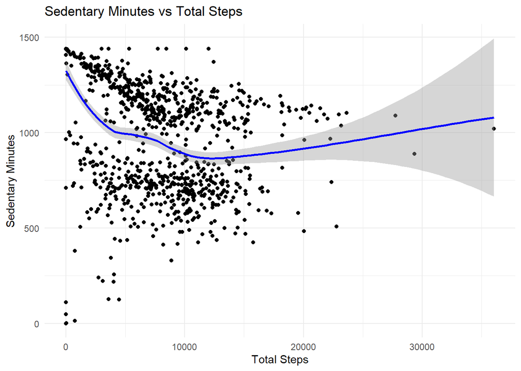

```r
# Create the scatter plot with axis labels and a smoothing line
ggplot(data=daily_activity, aes(x=TotalSteps, y=SedentaryMinutes)) +
  geom_point() +
  geom_smooth(method="loess", se=TRUE, color="blue") +
  labs(
    title = "Sedentary Minutes vs Total Steps",
    x = "Total Steps",
    y = "Sedentary Minutes"
  ) +
  theme_minimal()
```

Check the corelation between TotalSteps and SedentaryMinutes

```r
cor.test(daily_activity$TotalSteps, daily_activity$SedentaryMinutes)
```

```
##
##  Pearson's product-moment correlation
##
## data:  daily_activity$TotalSteps and daily_activity$SedentaryMinutes
## t = -10.615, df = 938, p-value < 2.2e-16
## alternative hypothesis: true correlation is not equal to 0
## 95 percent confidence interval:
##  -0.3833971 -0.2691782
## sample estimates:
##        cor
## -0.3274835
```

#### Description:

The Pearson’s product-moment correlation analysis between TotalSteps and SedentaryMinutes in daily_activity indicates a statistically significant negative correlation (cor = -0.3274835, p < 2.2e-16). This negative correlation suggests that as the number of total steps increases, the time spent in sedentary activities decreases. In other words, higher physical activity (measured in steps) is associated with less sedentary behavior in the dataset.

See what’s the relationship between minutes asleep and time in bed

[figure not shown]

```r
# Create the scatter plot with axis labels and a smoothing line
ggplot(data=sleep_day, aes(x=TotalMinutesAsleep, y=TotalTimeInBed)) +
  geom_point() +
  geom_smooth(method="loess", se=FALSE, color="blue") +
  labs(
    title = "Total Time in Bed vs Total Minutes Asleep",
    x = "Total Time in Bed",
    y = "Total Minutes Asleep"
  ) +
  theme_minimal()
```

Check the corelation between TotalMinutesAsleep and TotalTimeInBed

```r
cor.test(sleep_day$TotalMinutesAsleep, sleep_day$TotalTimeInBed)
```

```
##
##  Pearson's product-moment correlation
##
## data:  sleep_day$TotalMinutesAsleep and sleep_day$TotalTimeInBed
## t = 51.483, df = 411, p-value < 2.2e-16
## alternative hypothesis: true correlation is not equal to 0
## 95 percent confidence interval:
##  0.9162253 0.9423445
## sample estimates:
##       cor
## 0.9304575
```

#### Description:

The Pearson’s product-moment correlation analysis between `TotalMinutesAsleep` and `TotalTimeInBed` in `sleep_day` shows a very strong positive correlation (cor = 0.9304575, p < 2.2e-16). This indicates that there is a high correlation between the total time spent asleep and the total time spent in bed. In other words, individuals who spend more time in bed tend to have longer periods of actual sleep, suggesting good alignment between time spent in bed and actual sleep duration in the dataset.

See what could these trends tell about how to help market this product Or areas where might want to explore further

```r
cor.test(sleep_day$TotalMinutesAsleep, sleep_day$TotalTimeInBed,
 alternative = "greater")
```

```
##
##  Pearson's product-moment correlation
##
## data:  sleep_day$TotalMinutesAsleep and sleep_day$TotalTimeInBed
## t = 51.483, df = 411, p-value < 2.2e-16
## alternative hypothesis: true correlation is greater than 0
## 95 percent confidence interval:
##  0.9186882 1.0000000
## sample estimates:
##       cor
## 0.9304575
```

#### Description:

Positive and strong correlation (close to 1) as expected.